# Report_Stage1

Mia, Junyi

2025-09-15

# Define the Problem

**The research question for this project is:** To what extent can Airbnb listing characteristics be used to classify whether a property is operated as a commercial year-round rental or as an occasional host-occupied rental?

**Problem as a Classification Task:** This is a classification problem with two outcomes: commercial year-round rental or occasional host-occupied rental. Predictions rely on listing features such as price, availability, reviews, and minimum nights.

**Relevance to Sydney and Australia:** Airbnb has a notable impact on Sydney’s housing market, where affordability is already a pressing issue. The growth of commercial short-term rentals reduces long-term housing supply and raises pressure on tenants. By classifying listings into commercial and occasional categories, this study highlights the scale of professional operations in Sydney and offers evidence to support housing policy in New South Wales and Australia.

# Describe the Data

**Data Source:** The dataset for comes from Inside Airbnb[🔗](https://insideairbnb.com), an independent project that collects and publishes Airbnb data on housing impacts. The data are obtained through web scraping and are publicly accessible. For this study, we use the detailed listings data for Sydney, New South Wales, dated 10 June 2025.

**Data Description:** The Sydney Airbnb dataset contains 18,187 observations and 79 variables, making it a tall dataset with more listings than attributes. Among the variables, 42 are numeric (27 integer and 15 double), 35 are categorical, and 2 are logical. This mix of quantitative and qualitative features provides the basis for classification. A complete listing of variables is provided in Appendix 1.

**Outcome Variable:** Dependent variable: binary categorical variable indicating rental type. This variable contain two outcome which is commercial where there’s always available, entire unit, multiple listings by host and occasional where there’s limited availability, host-occupied, fewer listings. Yet this metric it not in the raw data, we will construct it using availability_365, minimum_nights, host_total_listings_count and instant_bookable.

```r
orig_dim <- dim(orig_data)
n_rows <- orig_dim[1]; n_cols <- orig_dim[2]

tibble(
  Instances = n_rows,
  Attributes = n_cols,
  `p >> n?` = ifelse(n_cols > n_rows, "YES (wide dataset)", "NO")
) |>
  gt() |>
  tab_header(title = md("Table 1. Dataset Dimensions")) |>
  fmt_integer(columns = c(Instances, Attributes)) |>
  cols_align(align = "center")
```

Table 1. Dataset Dimensions

| Instances | Attributes | p >> n? |
| --- | --- | --- |
| 18,187 | 79 | NO |

```r
type_counts <- tibble(
  Numeric   = sum(map_lgl(orig_data, is.numeric)),
  Integer   = sum(map_lgl(orig_data, is.integer)),
  Double    = sum(map_lgl(orig_data, is.double)),
  Factor    = sum(map_lgl(orig_data, is.factor)),
  Character = sum(map_lgl(orig_data, is.character)),
  Logical   = sum(map_lgl(orig_data, is.logical))
) |>
  pivot_longer(everything(), names_to = "Type", values_to = "Count")

type_counts |>
  gt() |>
  tab_header(title = md("Table 2. Variable Type Counts")) |>
  fmt_integer(columns = Count) |>
  cols_align(align = "center")
```

Table 2. Variable Type Counts

| Type | Count |
| --- | --- |
| Numeric | 42 |
| Integer | 27 |
| Double | 15 |
| Factor | 0 |
| Character | 35 |
| Logical | 2 |

# Appendix

Appendix 1: Variable Description

```r
orig_dim = dim(orig_data)

dictionary_clean <- dictionary %>%
  select(Variable = 1, Description = 4)

description_table <- tibble(Variable = names(orig_data)) %>%
  mutate(Type = ifelse(sapply(orig_data, is.numeric), "Numeric", "Categorical"),
         Unique_Values = sapply(orig_data, function(x) n_distinct(x, na.rm = TRUE))) %>%
  left_join(dictionary_clean, by = "Variable") %>%
  select(Variable, Description, Type, Unique_Values)
```

| Variable | Description | Type | Unique_Values |
| --- | --- | --- | --- |
| id | Airbnb's unique identifier for the listing | Numeric | 18187 |
| listing_url |  | Categorical | 18187 |
| scrape_id | Inside Airbnb "Scrape" this was part of | Numeric | 1 |
| last_scraped | UTC. The date and time this listing was "scraped". | Categorical | 2 |
| source | One of "neighbourhood search" or "previous scrape". "neig... | Categorical | 2 |
| source |  | Categorical | 2 |
| name | Name of the listing | Categorical | 17704 |
| description | Detailed description of the listing | Categorical | 16379 |
| neighborhood_overview | Host's description of the neighbourhood | Categorical | 6764 |
| picture_url | URL to the Airbnb hosted regular sized image for the listing | Categorical | 17854 |
| host_id | Airbnb's unique identifier for the host/user | Numeric | 9122 |
| host_url | The Airbnb page for the host | Categorical | 9122 |
| host_name | Name of the host. Usually just the first name(s). | Categorical | 3909 |
| host_since | The date the host/user was created. For hosts that are Ai... | Categorical | 3953 |
| host_location | The host's self reported location | Categorical | 725 |
| host_about | Description about the host | Categorical | 4404 |
| host_response_time |  | Categorical | 6 |
| host_response_rate |  | Categorical | 53 |
| host_acceptance_rate | That rate at which a host accepts booking requests. | Categorical | 101 |
| host_is_superhost |  | Categorical | 3 |
| host_thumbnail_url |  | Categorical | 8750 |
| host_picture_url |  | Categorical | 8750 |
| host_neighbourhood |  | Categorical | 183 |
| host_listings_count | The number of listings the host has (per Airbnb unknown c... | Numeric | 94 |
| host_total_listings_count | The number of listings the host has (per Airbnb unknown c... | Numeric | 135 |
| host_verifications |  | Categorical | 8 |
| host_has_profile_pic |  | Categorical | 3 |
| host_identity_verified |  | Categorical | 3 |
| neighbourhood |  | Categorical | 2 |
| neighbourhood_cleansed | The neighbourhood as geocoded using the latitude and long... | Categorical | 38 |
| neighbourhood_group_cleansed | The neighbourhood group as geocoded using the latitude an... | Categorical | 0 |
| latitude | Uses the World Geodetic System (WGS84) projection for lat... | Numeric | 15165 |
| longitude | Uses the World Geodetic System (WGS84) projection for lat... | Numeric | 15367 |
| property_type | Self selected property type. Hotels and Bed and Breakfast... | Categorical | 69 |
| room_type | [Entire home/apt\|Private room\|Shared room\|Hotel] All hom... | Categorical | 4 |
| accommodates | The maximum capacity of the listing | Numeric | 16 |
| bathrooms | The number of bathrooms in the listing | Numeric | 20 |
| bathrooms_text | The number of bathrooms in the listing. On the Airbnb we... | Categorical | 33 |
| bedrooms | The number of bedrooms | Numeric | 14 |
| beds | The number of bed(s) | Numeric | 21 |
| amenities |  | Categorical | 17301 |
| price | daily price in local currency. NOTE: the $ sign is a tech... | Categorical | 1302 |
| minimum_nights | minimum number of night stay for the listing (calendar ru... | Numeric | 75 |
| maximum_nights | maximum number of night stay for the listing (calendar ru... | Numeric | 183 |
| minimum_minimum_nights | the smallest minimum_night value from the calender (looki... | Numeric | 75 |
| maximum_minimum_nights | the largest minimum_night value from the calender (lookin... | Numeric | 90 |
| minimum_maximum_nights | the smallest maximum_night value from the calender (looki... | Numeric | 172 |
| maximum_maximum_nights | the largest maximum_night value from the calender (lookin... | Numeric | 170 |
| minimum_nights_avg_ntm | the average minimum_night value from the calender (lookin... | Numeric | 434 |
| maximum_nights_avg_ntm | the average maximum_night value from the calender (lookin... | Numeric | 504 |
| calendar_updated |  | Categorical | 0 |
| has_availability | [t=true; f=false] | Categorical | 2 |
| availability_30 | avaliability_x. The availability of the listing x days in... | Numeric | 31 |
| availability_60 | avaliability_x. The availability of the listing x days in... | Numeric | 61 |
| availability_90 | avaliability_x. The availability of the listing x days in... | Numeric | 91 |
| availability_365 | avaliability_x. The availability of the listing x days in... | Numeric | 366 |
| calendar_last_scraped |  | Categorical | 2 |
| number_of_reviews | The number of reviews the listing has | Numeric | 466 |
| number_of_reviews_ltm | The number of reviews the listing has (in the last 12 mon... | Numeric | 123 |
| number_of_reviews_l30d | The number of reviews the listing has (in the last 30 days) | Numeric | 15 |
| availability_eoy | NA | Numeric | 198 |
| number_of_reviews_ly | NA | Numeric | 122 |
| estimated_occupancy_l365d | NA | Numeric | 91 |
| estimated_revenue_l365d | NA | Numeric | 4731 |
| first_review | The date of the first/oldest review | Categorical | 3241 |
| last_review | The date of the last/newest review | Categorical | 1341 |
| review_scores_rating |  | Numeric | 153 |
| review_scores_accuracy |  | Numeric | 150 |
| review_scores_cleanliness |  | Numeric | 181 |
| review_scores_checkin |  | Numeric | 144 |
| review_scores_communication |  | Numeric | 131 |
| review_scores_location |  | Numeric | 124 |
| review_scores_value |  | Numeric | 164 |
| license | The licence/permit/registration number | Categorical | 11200 |
| instant_bookable | [t=true; f=false]. Whether the guest can automatically bo... | Categorical | 2 |
| calculated_host_listings_count | The number of listings the host has in the current scrape... | Numeric | 63 |
| calculated_host_listings_count_entire_homes | The number of Entire home/apt listings the host has in th... | Numeric | 62 |
| calculated_host_listings_count_private_rooms | The number of Private room listings the host has in the c... | Numeric | 28 |
| calculated_host_listings_count_shared_rooms | The number of Shared room listings the host has in the cu... | Numeric | 5 |
| reviews_per_month | The average number of reviews per month the listing has o... | Numeric | 747 |

Appendix 2: Missing Value

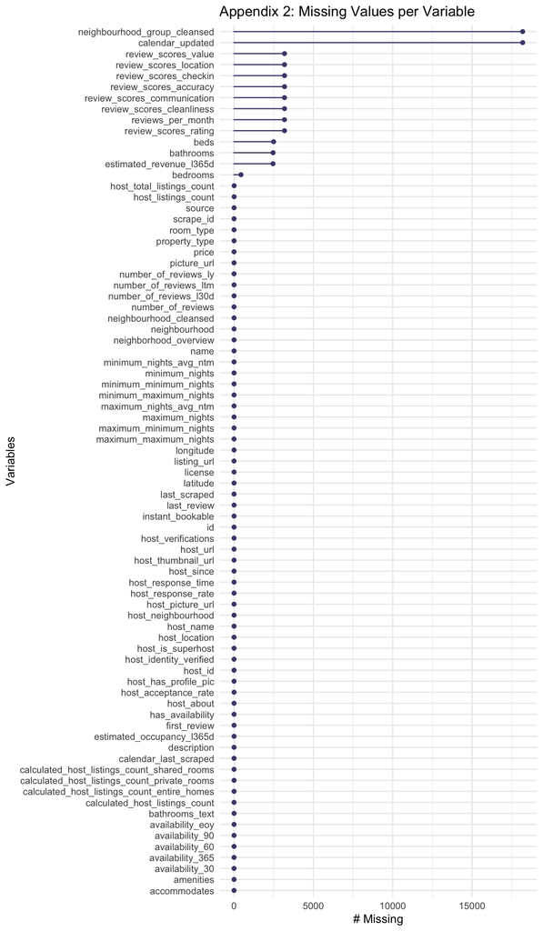